# Conductivity Investigation Winter 2022

Katheryn Rein

2024-04-15

# Purpose

This is a R Markdown HTML document to supplement DWR-1-INV-008 Conductivity Investigation Winter 2022 which explores cleaned up data compiled from samples collected between July 2022 and February 2023 that had both field and laboratory derived conductivity reported in the DWR Water Data Library (WDL).

Period of Concern: 11/01/2022-02/28/2023 Reference Period: 07/01/2022-10/31/2022

Relative percent differences (RPDs) between these field and laboratory reported values are evaluated here to explore relative percent differences (RPD) between DWR field and Bryte Lab specific conductance (SC) measurements. Samples collected between July 2022 and February 2023 are evaluated here. Data were exported from the WDL database. See “lab vs field sc investigation final code_v4.R” script for data cleaning and reorganization.

# Import and Prepare Data

Format data to evaluate differences between time periods of interest

Table A. Sample counts and date ranges for time periods of focus

| time_period_focus | n | min_date | max_date |
| --- | --- | --- | --- |
| 1 | 376 | 2022-11-01 | 2023-02-23 |
| 2 | 576 | 2022-07-05 | 2022-10-25 |

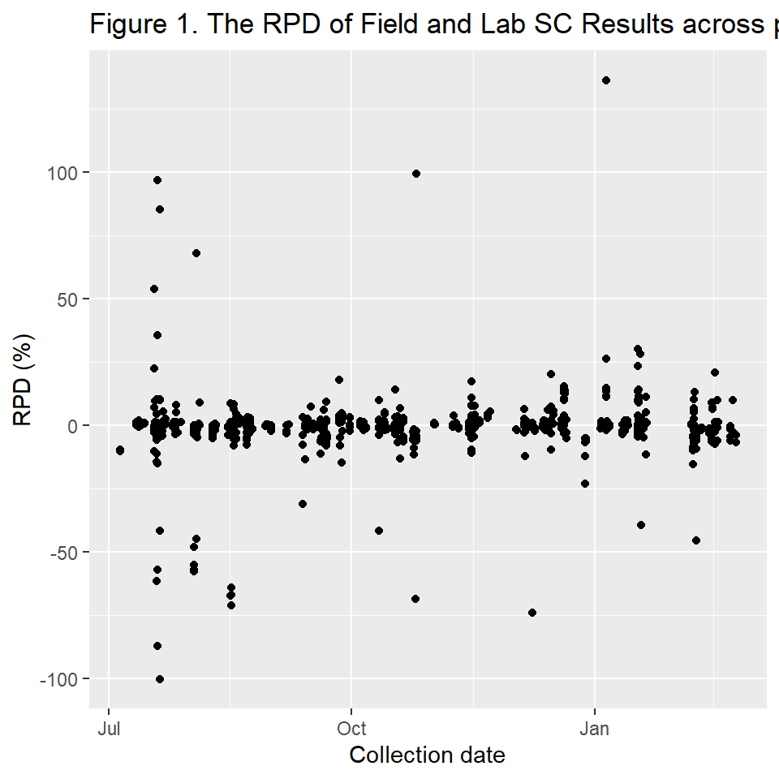

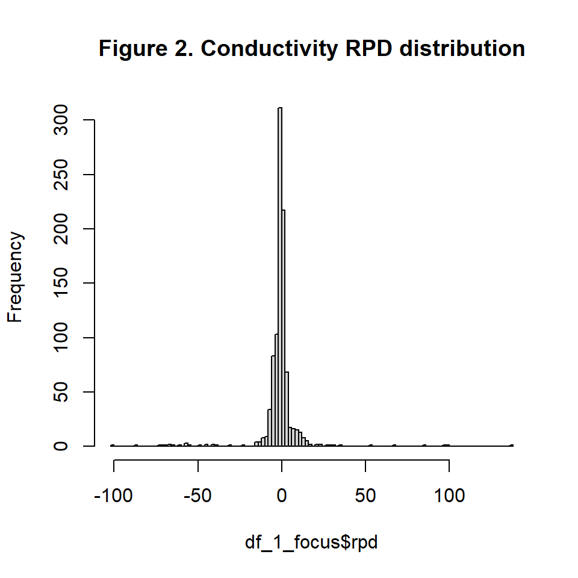

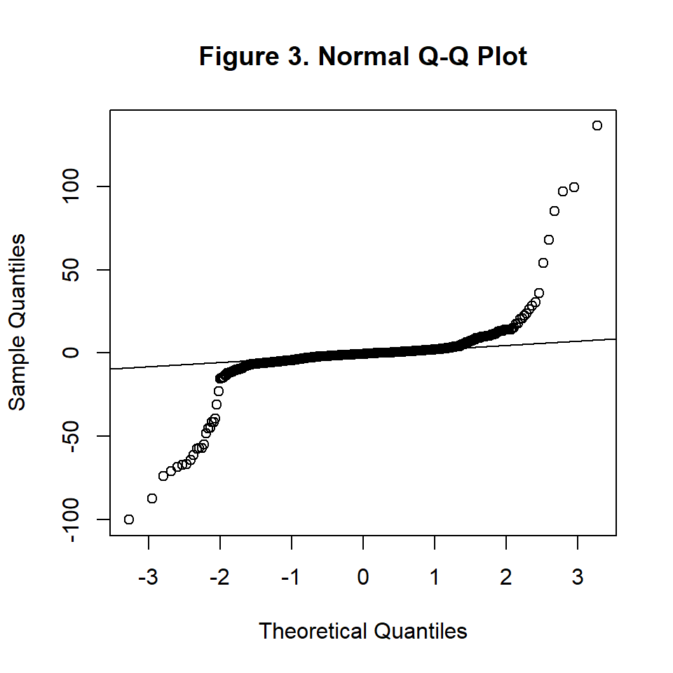

```
##    Min. 1st Qu.  Median    Mean 3rd Qu.    Max.
##    25.1   200.4   470.5  2861.3   772.0 44933.0
```

```
##    Min. 1st Qu.  Median    Mean 3rd Qu.    Max.
##    25.3   205.8   492.5  2809.1   787.5 44100.0
```

```
##      Min.   1st Qu.    Median      Mean   3rd Qu.      Max.
## -100.1546   -2.3656   -0.5698   -0.9322    1.0972  136.4122
```

```
##
##  Shapiro-Wilk normality test
##
## data:  df_1_focus$rpd
## W = 0.47879, p-value < 2.2e-16
```

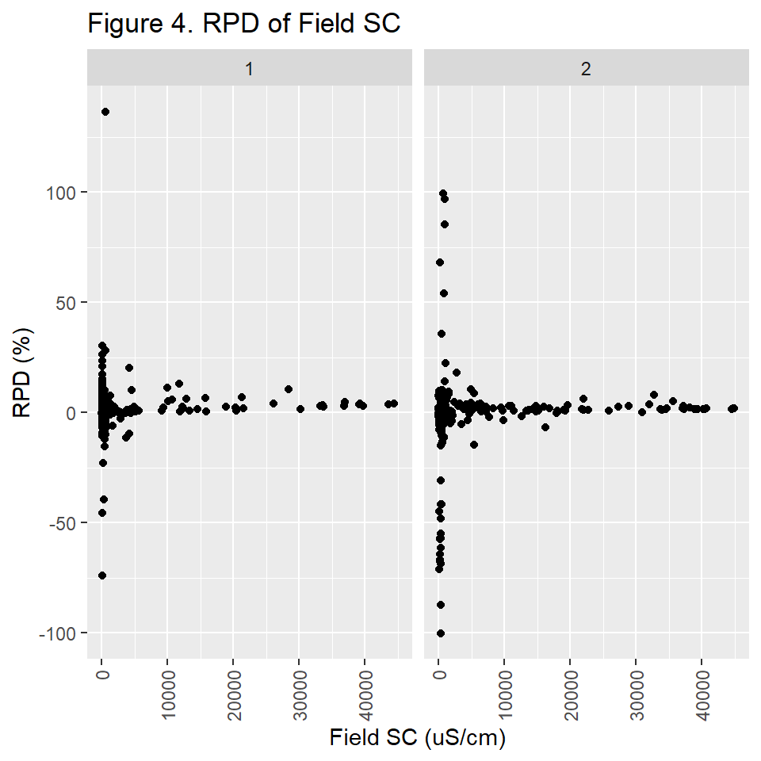

```
##
##  Shapiro-Wilk normality test
##
## data:  df_1_focus_below10K$rpd
## W = 0.47843, p-value < 2.2e-16
```

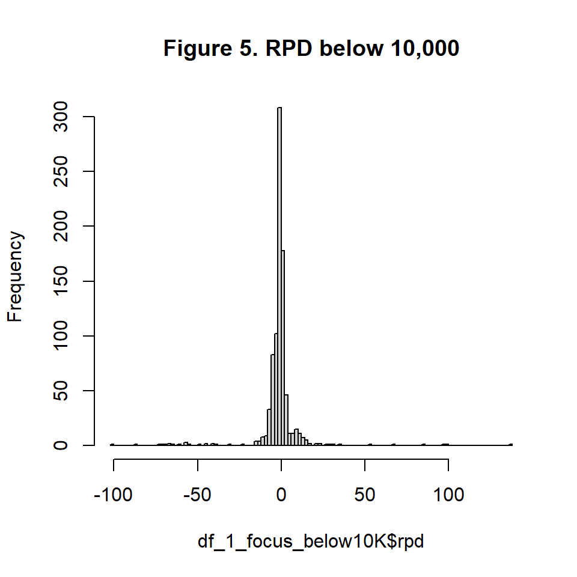

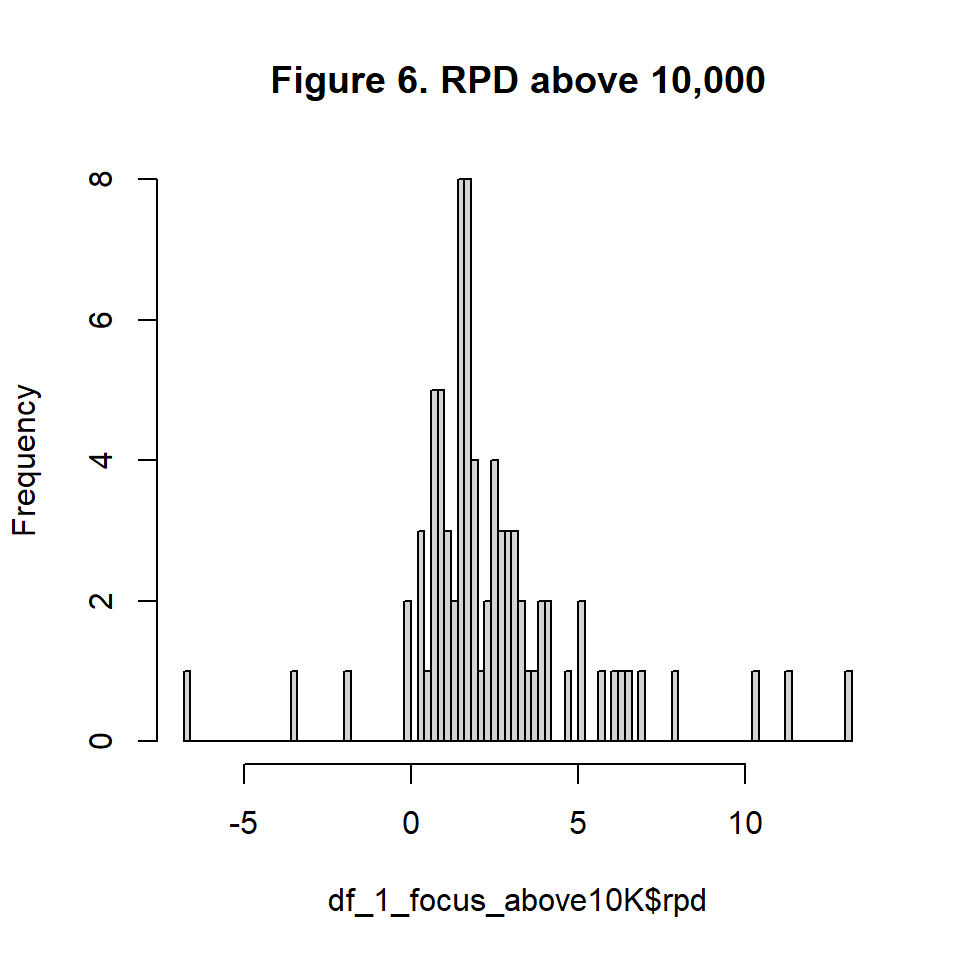

```
##
##  Shapiro-Wilk normality test
##
## data:  df_1_focus_above10K$rpd
## W = 0.85941, p-value = 3.399e-07
```

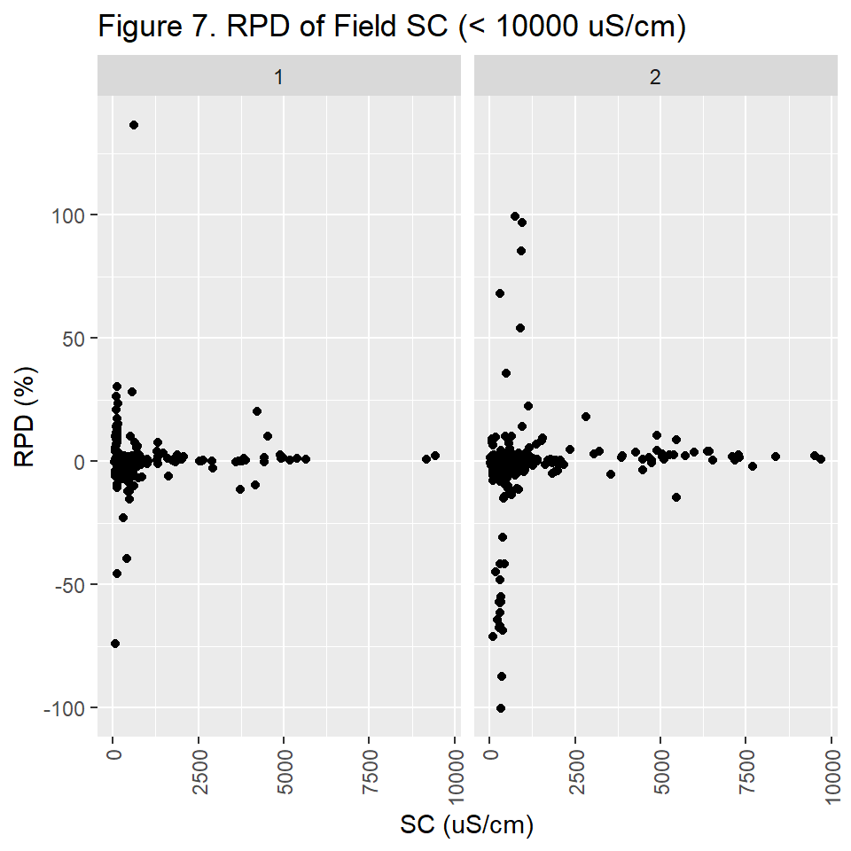

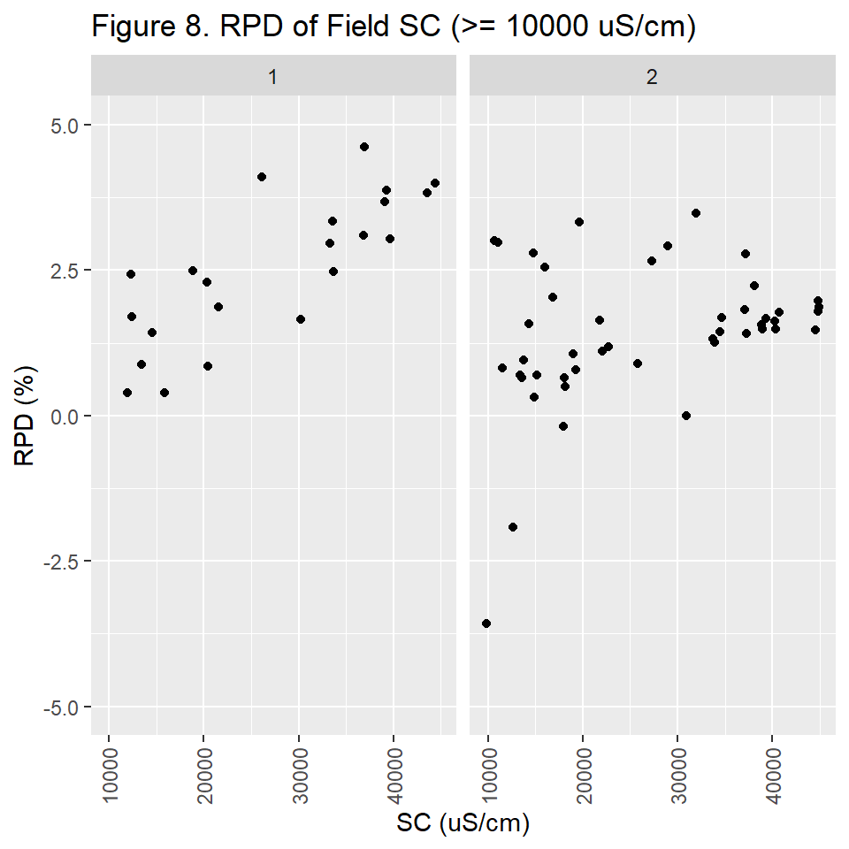

```
##
##  Shapiro-Wilk normality test
##
## data:  df_1_focus_t$rpd_sqr
## W = 0.13885, p-value < 2.2e-16
```

```
##
##  Shapiro-Wilk normality test
##
## data:  df_1_focus_t$log_abs_rpd
## W = 0.987, p-value = 1.804e-07
```

The RPD across the periods 1 & 2 (Fig. 1, Fig. 2) is not normally distributed (Fig. 3).The Shapiro-Wilk test did not find normality in the data or two transformations of it (p < 0.05). Data were filtered above and below 10,000 µS/cm and the normality of each dataset was also not normal.Higher RPDs are more commonly observed at specific conductance (SC) measurements < 10,000 µS/cm (Fig. 4, Fig. 5).

Conductivity sensors used in the field are not commonly calibrated below 1000 microseimens per centimeter (µS/cm) per the manufacturers recommendations. Current department guidance includes field programs checking the conductivity sensor to ensure the sensor reads < 5 µS/cm in air.

# Summary Tables

Sample counts and RPDs across period of interest and reference period and filtered for above and below 10,000 uS/cm

Table 1. SC Measurements across period of concern and reference period

| time_period_focus | n | min_field_SC | max_field_SC | min_lab_SC | max_lab_sc | min_rpd | max_rpd | mean_rpd | median_rpd |
| --- | --- | --- | --- | --- | --- | --- | --- | --- | --- |
| 1 | 376 | 49 | 44,443 | 49 | 42,700 | -73.89 | 136.41 | 0.28 | -0.32 |
| 2 | 576 | 25 | 44,933 | 25 | 44,100 | -100.15 | 99.39 | -1.73 | -0.60 |

Table 2. SC Measurements < 10,000 uS/cm across period of concern and reference period

| time_period_focus | n | min_field_SC | max_field_SC | min_lab_SC | max_lab_sc | min_rpd | max_rpd | mean_rpd | median_rpd |
| --- | --- | --- | --- | --- | --- | --- | --- | --- | --- |
| 1 | 346 | 49 | 9,440 | 49 | 9,240 | -73.89 | 136.41 | -0.04 | -0.71 |
| 2 | 526 | 25 | 9,702 | 25 | 9,620 | -100.15 | 99.39 | -2.04 | -0.83 |

Table 3. SC Measurements > 10,000 uS/cm across period of concern and reference period

| time_period_focus | n | min_field_SC | max_field_SC | min_lab_SC | max_lab_sc | min_rpd | max_rpd | mean_rpd | median_rpd |
| --- | --- | --- | --- | --- | --- | --- | --- | --- | --- |
| 1 | 30 | 10,004 | 44,443 | 8,940 | 42,700 | 0.39 | 13.08 | 4.02 | 3.22 |
| 2 | 50 | 9,841 | 44,933 | 10,200 | 44,100 | -6.60 | 8.00 | 1.54 | 1.52 |

Table 5. Conductivity Summary by Group and Time Period

| data_owner_id | time_period_focus | n | min_field_SC | max_field_SC | min_lab_SC | max_lab_SC | min_rpd | max_rpd | mean_rpd | median_rpd |
| --- | --- | --- | --- | --- | --- | --- | --- | --- | --- | --- |
| 0310 | 1 | 106 | 115 | 44,443 | 118 | 42,700 | -39.53 | 20.24 | 0.94 | 0.86 |
| 0310 | 2 | 110 | 119 | 44,933 | 120 | 44,100 | -6.60 | 14.21 | 0.85 | 0.65 |
| 1860 | 1 | 15 | 67 | 696 | 64 | 688 | -73.89 | 5.33 | -3.73 | 0.79 |
| 1860 | 2 | 32 | 57 | 1,080 | 56 | 1,080 | -1.79 | 8.92 | 0.46 | 0.03 |
| 2040 | 1 | 152 | 49 | 1,906 | 49 | 1,890 | -15.24 | 136.41 | 2.88 | -0.18 |
| 2040 | 2 | 162 | 49 | 712 | 50 | 701 | -71.19 | 9.82 | -5.09 | -1.00 |
| 4804 | 1 | 53 | 63 | 847 | 66 | 904 | -45.53 | 20.75 | -5.67 | -5.49 |
| 4804 | 2 | 172 | 75 | 1,125 | 75 | 1,080 | -100.15 | 99.39 | -1.60 | -2.10 |
| 6301 | 1 | 36 | 288 | 3,793 | 292 | 3,790 | -3.60 | 5.41 | -0.38 | -0.83 |
| 6301 | 2 | 60 | 25 | 2,070 | 25 | 2,060 | -2.29 | 9.40 | 0.53 | 0.15 |
| 7200 | 1 | 14 | 132 | 12,887 | 139 | 12,100 | -23.08 | 6.30 | -4.46 | -3.85 |
| 7200 | 2 | 40 | 315 | 25,831 | 338 | 25,600 | -41.72 | 17.90 | -0.84 | 2.10 |

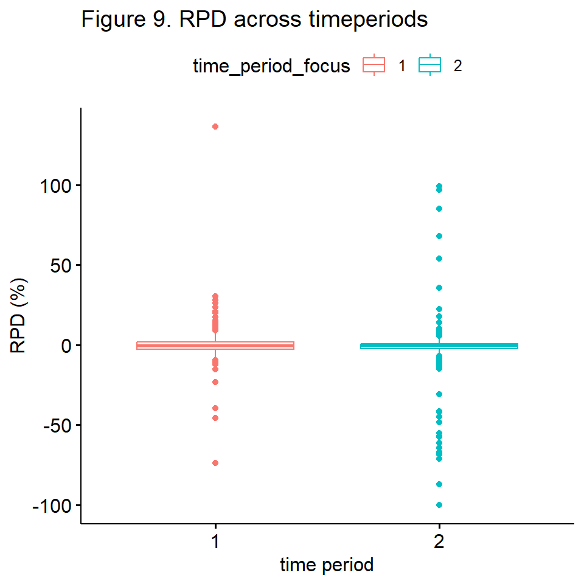

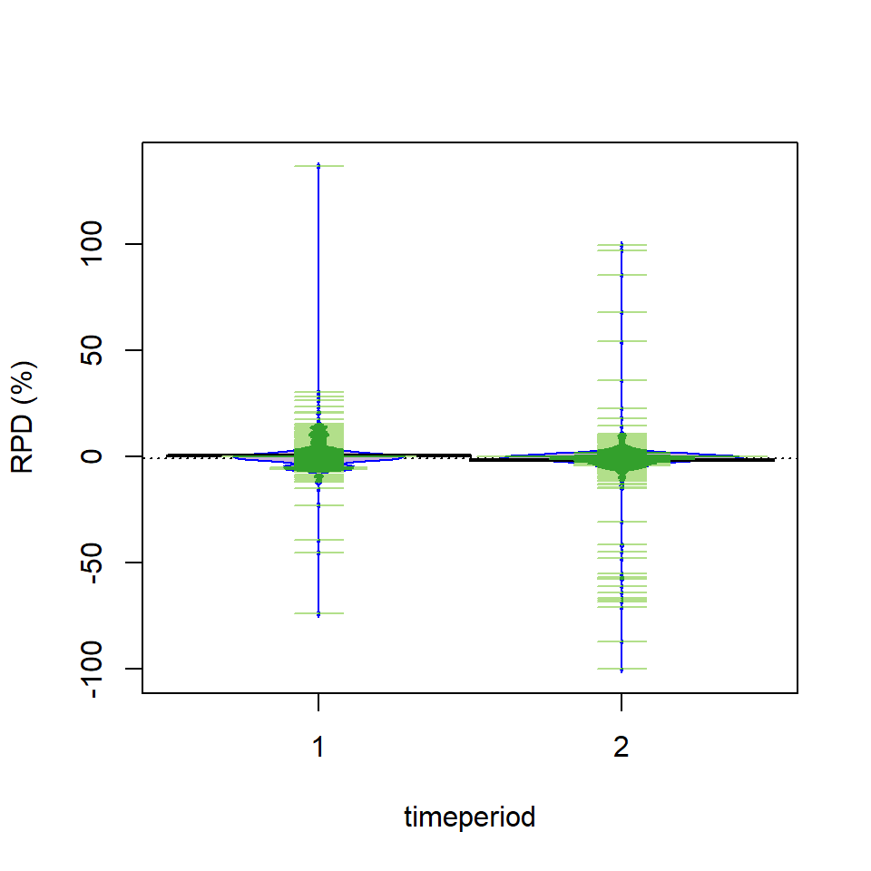

```
##
##  Kruskal-Wallis rank sum test
##
## data:  rpd by time_period_focus
## Kruskal-Wallis chi-squared = 4.1275, df = 1, p-value = 0.04219
```

```
##
##  Kruskal-Wallis rank sum test
##
## data:  rpd by time_period_focus
## Kruskal-Wallis chi-squared = 2.4167, df = 1, p-value = 0.12
```

```
##
##  Kruskal-Wallis rank sum test
##
## data:  rpd by time_period_focus
## Kruskal-Wallis chi-squared = 16.522, df = 1, p-value = 4.81e-05
```

```
##
##  Kruskal-Wallis rank sum test
##
## data:  rpd by time_period_focus
## Kruskal-Wallis chi-squared = 3.8644, df = 1, p-value = 0.04932
```

Look for statistical difference within each field program between period of concern and reference period

Table 4. Sample counts across period of concern and reference period by data owner

| data_owner_id | n_1 | n_2 | min_SC_1 | min_SC_2 | max_SC_1 | max_SC_2 |
| --- | --- | --- | --- | --- | --- | --- |
| 0310 | 106 | 110 | 115 | 119 | 44,443 | 44,933 |
| 1860 | 15 | 32 | 67 | 57 | 696 | 1,080 |
| 2040 | 152 | 162 | 49 | 49 | 1,906 | 712 |
| 4804 | 53 | 172 | 63 | 75 | 847 | 1,125 |
| 6301 | 36 | 60 | 288 | 25 | 3,793 | 2,070 |
| 7200 | 14 | 40 | 132 | 315 | 12,887 | 25,831 |

```
##  long_station_name  data_owner_id      dwr_sample_code
##  Length:216         Length:216         Length:216
##  Class :character   Class :character   Class :character
##  Mode  :character   Mode  :character   Mode  :character
##
##
##
##  collection_date2                   lab_result       field_result
##  Min.   :2022-07-18 08:45:00.00   Min.   :  118.0   Min.   :  115.0
##  1st Qu.:2022-08-23 13:05:00.00   1st Qu.:  473.5   1st Qu.:  462.2
##  Median :2022-10-20 11:35:00.00   Median : 2290.0   Median : 2277.0
##  Mean   :2022-10-30 22:14:36.39   Mean   : 9937.9   Mean   :10170.1
##  3rd Qu.:2022-12-20 10:05:00.00   3rd Qu.:15650.0   3rd Qu.:15898.2
##  Max.   :2023-02-16 14:50:00.00   Max.   :44100.0   Max.   :44933.0
##       rpd           time_period_focus
##  Min.   :-39.5326   Min.   :1.000
##  1st Qu.: -0.7500   1st Qu.:1.000
##  Median :  0.6900   Median :2.000
##  Mean   :  0.8963   Mean   :1.509
##  3rd Qu.:  2.1436   3rd Qu.:2.000
##  Max.   : 20.2423   Max.   :2.000
```

```
##
##  Shapiro-Wilk normality test
##
## data:  df_0310$rpd
## W = 0.69331, p-value < 2.2e-16
```

```
##
##  Shapiro-Wilk normality test
##
## data:  df_0310_below10K$rpd
## W = 0.61913, p-value < 2.2e-16
```

```
##
##  Shapiro-Wilk normality test
##
## data:  df_0310_above10K$rpd
## W = 0.85165, p-value = 3.691e-07
```

```
##
##  Kruskal-Wallis rank sum test
##
## data:  rpd by time_period_focus
## Kruskal-Wallis chi-squared = 0.3934, df = 1, p-value = 0.5305
```

```
##
##  Kruskal-Wallis rank sum test
##
## data:  rpd by time_period_focus
## Kruskal-Wallis chi-squared = 0.076999, df = 1, p-value = 0.7814
```

```
##
##  Kruskal-Wallis rank sum test
##
## data:  rpd by time_period_focus
## Kruskal-Wallis chi-squared = 16.291, df = 1, p-value = 5.431e-05
```

```
##  long_station_name  data_owner_id      dwr_sample_code
##  Length:47          Length:47          Length:47
##  Class :character   Class :character   Class :character
##  Mode  :character   Mode  :character   Mode  :character
##
##
##
##  collection_date2                   lab_result      field_result
##  Min.   :2022-07-12 09:20:00.00   Min.   :  56.3   Min.   :  57.1
##  1st Qu.:2022-08-04 11:00:00.00   1st Qu.: 132.0   1st Qu.: 126.0
##  Median :2022-09-15 10:00:00.00   Median : 294.0   Median : 293.4
##  Mean   :2022-09-28 23:40:08.94   Mean   : 306.7   Mean   : 305.6
##  3rd Qu.:2022-11-08 23:55:00.00   3rd Qu.: 427.0   3rd Qu.: 426.8
##  Max.   :2023-02-07 13:45:00.00   Max.   :1080.0   Max.   :1080.0
##       rpd           time_period_focus
##  Min.   :-73.8878   Min.   :1.000
##  1st Qu.: -0.1842   1st Qu.:1.000
##  Median :  0.2065   Median :2.000
##  Mean   : -0.8773   Mean   :1.681
##  3rd Qu.:  0.9208   3rd Qu.:2.000
##  Max.   :  8.9213   Max.   :2.000
```

```
##
##  Shapiro-Wilk normality test
##
## data:  df_1860$rpd
## W = 0.25166, p-value = 4.226e-14
```

```
##
##  Kruskal-Wallis rank sum test
##
## data:  rpd by time_period_focus
## Kruskal-Wallis chi-squared = 6.2453, df = 1, p-value = 0.01245
```

```
##  long_station_name  data_owner_id      dwr_sample_code
##  Length:314         Length:314         Length:314
##  Class :character   Class :character   Class :character
##  Mode  :character   Mode  :character   Mode  :character
##
##
##
##  collection_date2                  lab_result      field_result
##  Min.   :2022-07-05 06:40:00.0   Min.   :  49.0   Min.   :  48.9
##  1st Qu.:2022-08-23 17:17:45.0   1st Qu.: 123.2   1st Qu.: 133.0
##  Median :2022-10-18 22:50:00.0   Median : 499.0   Median : 473.0
##  Mean   :2022-10-29 10:54:38.5   Mean   : 400.5   Mean   : 391.4
##  3rd Qu.:2023-01-03 10:19:15.0   3rd Qu.: 561.0   3rd Qu.: 555.5
##  Max.   :2023-02-23 12:00:00.0   Max.   :1890.0   Max.   :1906.0
##       rpd           time_period_focus
##  Min.   :-71.1864   Min.   :1.000
##  1st Qu.: -2.3634   1st Qu.:1.000
##  Median : -0.6042   Median :2.000
##  Mean   : -1.2287   Mean   :1.516
##  3rd Qu.:  0.9351   3rd Qu.:2.000
##  Max.   :136.4122   Max.   :2.000
```

```
##
##  Shapiro-Wilk normality test
##
## data:  df_2040$rpd
## W = 0.51397, p-value < 2.2e-16
```

```
##
##  Kruskal-Wallis rank sum test
##
## data:  rpd by time_period_focus
## Kruskal-Wallis chi-squared = 20.861, df = 1, p-value = 4.94e-06
```

```
##  long_station_name  data_owner_id      dwr_sample_code
##  Length:225         Length:225         Length:225
##  Class :character   Class :character   Class :character
##  Mode  :character   Mode  :character   Mode  :character
##
##
##
##  collection_date2                   lab_result      field_result
##  Min.   :2022-07-18 08:00:00.00   Min.   :  65.9   Min.   :  63.0
##  1st Qu.:2022-08-03 06:20:00.00   1st Qu.: 162.0   1st Qu.: 157.0
##  Median :2022-09-20 10:00:00.00   Median : 273.0   Median : 270.0
##  Mean   :2022-10-06 12:22:46.67   Mean   : 331.1   Mean   : 324.1
##  3rd Qu.:2022-10-25 13:30:00.00   3rd Qu.: 412.0   3rd Qu.: 397.0
##  Max.   :2023-02-15 12:10:00.00   Max.   :1080.0   Max.   :1125.0
##       rpd           time_period_focus
##  Min.   :-100.155   Min.   :1.000
##  1st Qu.:  -5.295   1st Qu.:2.000
##  Median :  -2.817   Median :2.000
##  Mean   :  -2.561   Mean   :1.764
##  3rd Qu.:  -1.143   3rd Qu.:2.000
##  Max.   :  99.391   Max.   :2.000
```

```
##
##  Shapiro-Wilk normality test
##
## data:  df_4804$rpd
## W = 0.44369, p-value < 2.2e-16
```

```
##
##  Kruskal-Wallis rank sum test
##
## data:  rpd by time_period_focus
## Kruskal-Wallis chi-squared = 49.597, df = 1, p-value = 1.888e-12
```

```
##  long_station_name  data_owner_id      dwr_sample_code
##  Length:96          Length:96          Length:96
##  Class :character   Class :character   Class :character
##  Mode  :character   Mode  :character   Mode  :character
##
##
##
##  collection_date2                   lab_result      field_result
##  Min.   :2022-07-11 11:26:00.00   Min.   :  25.3   Min.   :  25.1
##  1st Qu.:2022-09-13 11:48:30.00   1st Qu.: 405.0   1st Qu.: 398.1
##  Median :2022-10-18 07:21:30.00   Median : 725.0   Median : 714.5
##  Mean   :2022-10-20 16:44:36.25   Mean   : 890.8   Mean   : 896.9
##  3rd Qu.:2022-12-02 10:38:30.00   3rd Qu.:1222.5   3rd Qu.:1232.0
##  Max.   :2023-02-16 09:45:00.00   Max.   :3790.0   Max.   :3793.0
##       rpd         time_period_focus
##  Min.   :-3.597   Min.   :1.000
##  1st Qu.:-1.077   1st Qu.:1.000
##  Median : 0.000   Median :2.000
##  Mean   : 0.192   Mean   :1.625
##  3rd Qu.: 0.506   3rd Qu.:2.000
##  Max.   : 9.395   Max.   :2.000
```

```
##
##  Shapiro-Wilk normality test
##
## data:  df_6301$rpd
## W = 0.79681, p-value = 3.493e-10
```

```
##
##  Kruskal-Wallis rank sum test
##
## data:  rpd by time_period_focus
## Kruskal-Wallis chi-squared = 6.719, df = 1, p-value = 0.009539
```

```
##  long_station_name  data_owner_id      dwr_sample_code
##  Length:54          Length:54          Length:54
##  Class :character   Class :character   Class :character
##  Mode  :character   Mode  :character   Mode  :character
##
##
##
##  collection_date2                   lab_result       field_result
##  Min.   :2022-09-12 09:20:00.00   Min.   :  139.0   Min.   :  132.3
##  1st Qu.:2022-09-26 11:16:45.00   1st Qu.:  599.5   1st Qu.:  585.2
##  Median :2022-09-27 09:48:00.00   Median : 2990.0   Median : 2992.0
##  Mean   :2022-10-17 09:02:13.32   Mean   : 4212.8   Mean   : 4277.2
##  3rd Qu.:2022-11-21 15:49:15.00   3rd Qu.: 5600.0   3rd Qu.: 5595.5
##  Max.   :2022-12-28 13:35:00.00   Max.   :25600.0   Max.   :25831.0
##       rpd          time_period_focus
##  Min.   :-41.723   Min.   :1.000
##  1st Qu.: -4.617   1st Qu.:1.250
##  Median :  1.703   Median :2.000
##  Mean   : -1.780   Mean   :1.741
##  3rd Qu.:  2.766   3rd Qu.:2.000
##  Max.   : 17.901   Max.   :2.000
```

```
##
##  Shapiro-Wilk normality test
##
## data:  df_7200$rpd
## W = 0.77094, p-value = 8.826e-08
```

```
##
##  Shapiro-Wilk normality test
##
## data:  df_7200_below10K$rpd
## W = 0.78731, p-value = 5.539e-07
```

```
##
##  Shapiro-Wilk normality test
##
## data:  df_7200_above10K$rpd
## W = 0.91502, p-value = 0.4983
```

```
##
##  Kruskal-Wallis rank sum test
##
## data:  rpd by time_period_focus
## Kruskal-Wallis chi-squared = 6.284, df = 1, p-value = 0.01218
```

```
##
##  Kruskal-Wallis rank sum test
##
## data:  rpd by time_period_focus
## Kruskal-Wallis chi-squared = 7.5082, df = 1, p-value = 0.006142
```